# Priors in R-INLA

So far used diffuse priors. Now need to think about how you change them in INLA.

Using diffuse priors may be ok for simple models, or a single random effect but becomes more important if you want to include a number of random effects.

We are going to continue with our BU model from before, using the binomial mixed effects model to begin with.

Again we add our fake grouping variable.

```r
library(tidyverse)
library(INLA)
bu<-read_csv("template_BU.csv")
bu$Random<-NA
bu$Random[1:45]<-"A"; bu$Random[46:200]<-"B"; bu$Random[201:295]<-"C"
bu$Random<-as.factor(bu$Random)
```

First we run the model:

E(BU_TOT) = mu_i + a_i (our random effect)

```r
f5 <- BU_TOT ~ Forest +  MeanNDVI + MeanTemp + ShrGra + f(Random, model = "iid")
TOT_POP<-bu$TOT_POP #our n trials
I5 <- inla(f5,
           family = "binomial",
           control.compute = list(dic = TRUE, waic = TRUE),
           control.predictor = list(compute = TRUE),
           Ntrials = TOT_POP,
           data = bu)
summary(I5)
```

```
Call:
c("inla(formula = f5, family = \"binomial\", data = bu, Ntrials = TOT_POP, ",  "    control.compute = list(dic = TRUE, waic = TRUE), control.predictor = list(compute = TRUE))" )

Time used:
 Pre-processing    Running inla Post-processing           Total
         2.3713          3.1831          0.5807          6.1351

Fixed effects:
                 mean     sd 0.025quant  0.5quant 0.975quant      mode
(Intercept) -118.1287 4.1123  -126.2051 -118.1280  -110.0635 -118.1263
Forest        -5.6618 1.1531    -7.9810   -5.6428    -3.4489   -5.6043
MeanNDVI       5.8643 1.0624     3.7886    5.8608     7.9579    5.8537
MeanTemp       3.9681 0.1491     3.6753    3.9681     4.2606    3.9680
ShrGra        -1.2641 0.1484    -1.5555   -1.2640    -0.9730   -1.2640
            kld
(Intercept)   0
Forest        0
MeanNDVI      0
MeanTemp      0
ShrGra        0

Random effects:
Name      Model
 Random   IID model

Model hyperparameters:
                         mean       sd 0.025quant 0.5quant 0.975quant
Precision for Random 19133.16 17643.49     586.30 13808.92   66601.05
                       mode
Precision for Random 668.36

Expected number of effective parameters(std dev): 5.058(0.1364)
Number of equivalent replicates : 58.32

Deviance Information Criterion (DIC) ...: 2615.37
Effective number of parameters .........: 5.06

Watanabe-Akaike information criterion (WAIC) ...: 2737.75
Effective number of parameters .................: 110.10

Marginal log-Likelihood:  -1322.80
Posterior marginals for linear predictor and fitted values computed
```

Now, imagine our colleagues who also work on this published a paper which suggested that in Togo proximity to forest had a negative effect on contracting BU, with a slope of -.31 and an se of 0.01.

As we are now Bayesian, lets include that prior knowledge in our model.

Remember, INLA assumes that distributon for the betas is multivariate normal and independent ie N(mu, sigma^2).

In order to update our knowledge about forests, mu = estimate for the slope from our colleagues, sigma^2 is the standard error

So now, for forest we want to put a prior of (-0.31,0.01)

BUT

Inla uses precision, not sigma^2, so our first task is to convert from sigma^2 to precision (tau)

tau = 1/sigma^2

=1 / 0.01^2

= 10000

So for inla, our new prior for Forest is (-.31, 10000)

And we specify this using control.fixed

```r
# Next we fit a model in which all fixed parameters
f5 <- BU_TOT ~ Forest +  MeanNDVI + MeanTemp + ShrGra + f(Random, model = "iid")
TOT_POP<-bu$TOT_POP #our n trials
I6 <- inla(f5,
           family = "binomial",
           control.compute = list(dic = TRUE, waic = TRUE),
           control.predictor = list(compute = TRUE),
           control.fixed = list(
             mean = list(
               Forest = -0.31,
               MeanNDVI = 0,
               MeanTemp = 0,
               ShrGra = 0 ),
             prec = list(
               Forest = 10000,
               MeanNDVI = 0.001,
               MeanTemp = 0.001,
               ShrGra = 0.001
             ),
             mean.intercept = 0,
             prec.intercept = 0
           ),
           Ntrials = TOT_POP,
           data = bu)
summary(I6)
```

```
Call:
c("inla(formula = f5, family = \"binomial\", data = bu, Ntrials = TOT_POP, ",  "    control.compute = list(dic = TRUE, waic = TRUE), control.predictor = list(compute = TRUE), ",  "    control.fixed = list(mean = list(Forest = -0.31, MeanNDVI = 0, ",  "        MeanTemp = 0, ShrGra = 0), prec = list(F…

Time used:
 Pre-processing    Running inla Post-processing           Total
         2.7914          2.4269          0.5863          5.8046

Fixed effects:
                 mean     sd 0.025quant  0.5quant 0.975quant      mode
(Intercept) -116.2214 4.0354  -124.1401 -116.2231  -108.3008 -116.2262
Forest        -0.3105 0.0100    -0.3301   -0.3105    -0.2909   -0.3105
MeanNDVI       7.2632 1.0026     5.3099    7.2579     9.2441    7.2473
MeanTemp       3.8682 0.1463     3.5807    3.8683     4.1550    3.8685
ShrGra        -0.7989 0.1178    -1.0310   -0.7986    -0.5685   -0.7979
            kld
(Intercept)   0
Forest        0
MeanNDVI      0
MeanTemp      0
ShrGra        0

Random effects:
Name      Model
 Random   IID model

Model hyperparameters:
                         mean       sd 0.025quant 0.5quant 0.975quant
Precision for Random 19984.68 19701.95     538.58 13894.03   72976.56
                       mode
Precision for Random 147.05

Expected number of effective parameters(std dev): 4.066(0.1542)
Number of equivalent replicates : 72.55

Deviance Information Criterion (DIC) ...: 2638.20
Effective number of parameters .........: 4.075

Watanabe-Akaike information criterion (WAIC) ...: 2751.72
Effective number of parameters .................: 101.90

Marginal log-Likelihood:  -1332.01
Posterior marginals for linear predictor and fitted values computed
```

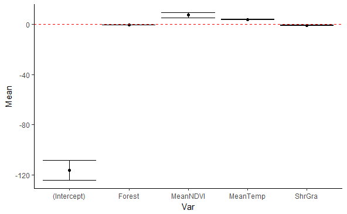

```r
round(I6$summary.fixed[, c("mean",
                              "0.025quant",
                              "0.975quant")],2)->betas
#Change the ros and headers as throws an error
betas$Var <- rownames(betas)
names(betas)<-c("Mean", "LowQ", "HiQ", "Var")
ggplot(betas)+geom_point(aes(Var, Mean))+geom_errorbar(aes(x = Var, ymax =  HiQ, ymin =  LowQ))+geom_hline(aes(yintercept = 0), col = 2, linetype = "dashed")+theme_classic()
```

Now “Forest” has tiny confidence intervals because we used a precise prior.

Realistic? Well, probably not for this model :)

What about hyper parameters?

This is more complicated and they often throw errors, so can take some fiddling.

Recap on hyperparameters:

These are eg the variances sigma^2 (for the normal distribution), or theta (negative binomial), variance parameters from random effects, parameters from spatial correlation function.

They must be positive, so cannot use the normal distribution for them. Instead use a distribution that is bounded at least by zero and 1 or infinity

E.g Uniform distribution or gamma distribution.

We have only got a hyperparameter for the random effect in the above model - if we were using normal distribution we would also have a prior for the residual variance.

If we were to use say the normal or the negative binomial distribution for our data, we set the hyperparameter for sigma/ theta using control.family, the gamma distribution is a good choice. Inla uses the loggamma distribution (if interested in the maths behind this –> either of the recommended books or inla course with Highland Statistics will explain more)

Going back to the linear model below, we will change the hyper parameter for theta to match the hyperparameter suggested by Carroll et al 2015 who carried out an extensive simulation study. Inla has a default prior on the precision parameter (the variance parameter) of 0.00005 for gamma. Carroll et al suggest that 0.5 may be better.

We change this in the control.family command:

```r
I7 <- inla(f5,
           control.compute = list(dic = TRUE),
           control.predictor = list(compute = TRUE),
           control.family = list( hyper = list(
                                prec = list(
                                  prior = "loggamma",
                                  param = c(1, 0.5)))),
           data = bu)
summary(I7)
```

```
Call:
c("inla(formula = f5, data = bu, control.compute = list(dic = TRUE), ",  "    control.predictor = list(compute = TRUE), control.family = list(hyper = list(prec = list(prior = \"loggamma\", ",  "        param = c(1, 0.5)))))")

Time used:
 Pre-processing    Running inla Post-processing           Total
         4.8148          7.2613          0.9057         12.9817

Fixed effects:
                mean      sd 0.025quant 0.5quant 0.975quant     mode
(Intercept) -59.2327 14.7689   -88.2501 -59.2333   -30.2405 -59.2334
Forest       -5.8317  3.4891   -12.6863  -5.8321     1.0180  -5.8325
MeanNDVI     -0.6152  3.3517    -7.2003  -0.6154     5.9643  -0.6154
MeanTemp      2.2558  0.5404     1.1940   2.2558     3.3166   2.2558
ShrGra       -0.4381  0.5303    -1.4799  -0.4381     0.6029  -0.4382
            kld
(Intercept)   0
Forest        0
MeanNDVI      0
MeanTemp      0
ShrGra        0

Random effects:
Name      Model
 Random   IID model

Model hyperparameters:
                                             mean        sd 0.025quant
Precision for the Gaussian observations 1.078e-01 8.900e-03   9.11e-02
Precision for Random                    1.880e+04 1.859e+04   1.28e+03
                                         0.5quant 0.975quant     mode
Precision for the Gaussian observations 1.075e-01  1.262e-01    0.107
Precision for Random                    1.331e+04  6.763e+04 3501.412

Expected number of effective parameters(std dev): 4.982(0.0221)
Number of equivalent replicates : 59.21

Deviance Information Criterion (DIC) ...: 1503.14
Effective number of parameters .........: 6.013

Marginal log-Likelihood:  -763.91
Posterior marginals for linear predictor and fitted values computed
```

For negative binomial, that requires setting the theta parameter.

I8 <- inla(f5, control.compute = list(dic = TRUE), control.predictor = list(compute = TRUE), family = “nbinomial”, control.family = list( hyper = list( theta = list( prior = “loggamma”, param = c(1, 0.5)))), data = bu)

# Priors on random effects

What about setting hyperparameters for random effects?

Set it in the random effects part of the code. For a random effect that is iid (independent and identically distributed) we assume normal distribution, in the below sample we update our precision prior (our sigma^2) to the one recommended by the Carroll et al 2015 paper.

Our model again:

BU_TOT_i ~ Bin(P_i,N_i) E(BU_i) = N_i * P_i (Number of trials * probability of event) + a_i (for the random variable) var(BU_i) = N_i*P_i*(1-P_i)

P_i = exp(Covariates) / 1+exp(Covariates)

where: a_i ~ N(0, sigmaRandom^2) (our random effect)

```r
f9 <- BU_TOT ~ Forest +  MeanNDVI + MeanTemp + ShrGra + f(Random, model = "iid", hyper = list( prec = list(prior = "loggamma",param = c(1, 0.5))))
TOT_POP<-bu$TOT_POP #our n trials
I9 <- inla(f9,
           family = "binomial",
           control.compute = list(dic = TRUE, waic = TRUE),
           control.predictor = list(compute = TRUE),
           control.fixed = list(
             mean = list(
               Forest = -0.31,
               MeanNDVI = 0,
               MeanTemp = 0,
               ShrGra = 0 ),
             prec = list(
               Forest = 10000,
               MeanNDVI = 0.001,
               MeanTemp = 0.001,
               ShrGra = 0.001
             ),
             mean.intercept = 0,
             prec.intercept = 0
           ),
           Ntrials = TOT_POP,
           data = bu)
summary(I9)
```

```
Call:
c("inla(formula = f9, family = \"binomial\", data = bu, Ntrials = TOT_POP, ",  "    control.compute = list(dic = TRUE, waic = TRUE), control.predictor = list(compute = TRUE), ",  "    control.fixed = list(mean = list(Forest = -0.31, MeanNDVI = 0, ",  "        MeanTemp = 0, ShrGra = 0), prec = list(F…

Time used:
 Pre-processing    Running inla Post-processing           Total
         3.2615          1.8917          0.1861          5.3393

Fixed effects:
                 mean     sd 0.025quant  0.5quant 0.975quant      mode
(Intercept) -119.2225 4.3479  -127.7618 -119.2218  -110.6953 -119.2199
Forest        -0.3105 0.0100    -0.3301   -0.3105    -0.2909   -0.3105
MeanNDVI       7.3714 1.0031     5.4166    7.3663     9.3527    7.3562
MeanTemp       3.9768 0.1569     3.6688    3.9768     4.2846    3.9768
ShrGra        -0.7093 0.1423    -0.9880   -0.7096    -0.4294   -0.7100
            kld
(Intercept)   0
Forest        0
MeanNDVI      0
MeanTemp      0
ShrGra        0

Random effects:
Name      Model
 Random   IID model

Model hyperparameters:
                      mean   sd 0.025quant 0.5quant 0.975quant  mode
Precision for Random 3.705 2.60     0.4552    3.107      10.27 1.843

Expected number of effective parameters(std dev): 5.927(0.0513)
Number of equivalent replicates : 49.77

Deviance Information Criterion (DIC) ...: 2638.23
Effective number of parameters .........: 5.924

Watanabe-Akaike information criterion (WAIC) ...: 2795.07
Effective number of parameters .................: 136.55

Marginal log-Likelihood:  -1333.92
Posterior marginals for linear predictor and fitted values computed
```

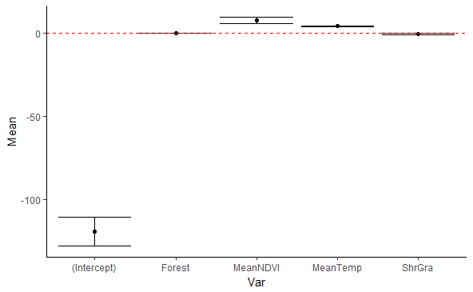

```r
round(I9$summary.fixed[, c("mean",
                              "0.025quant",
                              "0.975quant")],2)->betas
#Change the ros and headers as throws an error
betas$Var <- rownames(betas)
names(betas)<-c("Mean", "LowQ", "HiQ", "Var")
ggplot(betas)+geom_point(aes(Var, Mean))+geom_errorbar(aes(x = Var, ymax =  HiQ, ymin =  LowQ))+geom_hline(aes(yintercept = 0), col = 2, linetype = "dashed")+theme_classic()
```

In the above model we used informative priors for both our fixed effect “Forest” and our precision on the random effect “Random”

lets have a look at how the priors change the interpretation

Our two models we will compare are F5 and F9

```r
# Get the posterior distributions of tau and tau_Random
# Model with standard settings
#tau5     <- I5$marginals.hyperpar$`Precision for the Gaussian observations` = would include if was agaussian model
tauRand5 <- I5$marginals.hyperpar$`Precision for Random`
# Model with the gamma(1, 0.5) priors
#tau9     <- I9$marginals.hyperpar$`Precision for the Gaussian observations` would include if was a gaussian model
tauRand9 <- I9$marginals.hyperpar$`Precision for Random`
# gamma(1, 0.0005) priors
#sigma5     <- inla.emarginal(function(x) (1/sqrt(x)), tau5)
sigmaRand5 <- inla.emarginal(function(x) (1/sqrt(x)),tauRand5)
# gamma(1, 0.5) priors
#sigma9     <- inla.emarginal(function(x) (1/sqrt(x)), tau9)
sigmaRand9 <- inla.emarginal(function(x) (1/sqrt(x)),tauRand9)
sigmaRand5; sigmaRand9
```

```
[1] 0.01169823
[1] 0.6484119
```

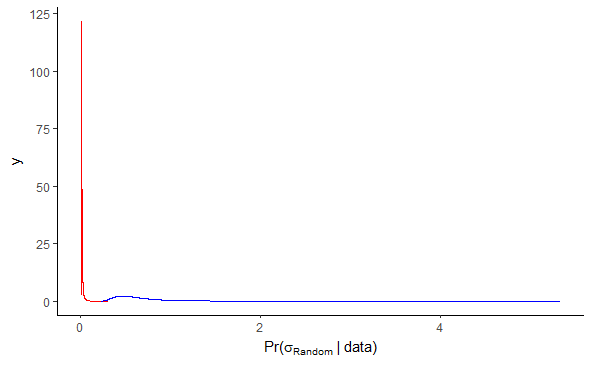

```r
# Sigma Rand is rather different for the gamma(1, 0.5) prior!
# Instead of looking at a number, we can also draw the
# distributions of the sigmas. These are the
# distributions for the sigma of the response variable:
# these are the distributions for sigma_Random
Posterior.SigmaRand5<- inla.tmarginal(function(x) (1/sqrt(x)),tauRand5)
Posterior.SigmaRand9 <- inla.tmarginal(function(x) (1/sqrt(x)),tauRand9)
ggplot(data.frame(Posterior.SigmaRand5))+geom_line(aes(x,y), col = "red")+geom_line(data = data.frame(Posterior.SigmaRand9), aes(x,y), col = "blue")+ xlab(expression(paste("Pr(", sigma[Random], " | data)")))+theme_classic()
```

Quite different!

Another type of prior you may come across is so called penalised complexity priors. These will appear when we discuss spatial autocorrelation